# Final P4

Jonah Smith

2025-04-19

Part iv: Interpretation – ivA) Input Importance • With the model training completed, you can now answer meaningful questions associated with the data!

• You must identify the best regression model and the best classification model.

BEST CLASSIFICATION MODEL Model: Random Forest (based on highest ROC from CV) Key Variables (from varImp(Random_Forest)): Dominant: Hue, Saturation, G Weaker: R, Lightness, B Interpretation: Similar to regression, Hue, G, and Saturation dominate. Lightness is less consistently important in classification.

Red shows up consistently less significant across both regression and classification tasks, even when included in pairwise models.

Though categorical inputs enhance prediction, color inputs alone can meaningfully predict popularity, especially with nonlinear or interaction modeling (e.g. Hue * Saturation, G * Saturation).

Part iv: Interpretation – ivB) Input insights • You must drill down further to gain additional insights into the patterns of the data! • You must identify the combinations of Lightness and Saturation: • That appear to be the HARDEST to predict in the regression and classification tasks • That appear to be the EASIEST to predict in the regression and classification tasks • Base your conclusions on the best performing regression and classification models. • You should base your conclusions on the resampled HOLD-OUT sets and NOT on the TRAINING set! • Thus, save your resampled hold-out set predictions! 33

```r
library(tidyverse)
```

```r
library(coefplot)
library(caret)
library(rstanarm)
library(pROC)
library(broom)
library(glmnet)
library(nnet)
library(tidyr)
library(bayesplot)
df <- readr::read_csv("paint_project_train_data.csv", col_names = TRUE)
glimpse(df)
```

```
## Rows: 835
## Columns: 8
## $ R          <dbl> 172, 26, 172, 28, 170, 175, 90, 194, 171, 122, 0, 88, 144, …
## $ G          <dbl> 58, 88, 94, 87, 66, 89, 78, 106, 68, 151, 121, 140, 82, 163…
## $ B          <dbl> 62, 151, 58, 152, 58, 65, 136, 53, 107, 59, 88, 58, 132, 50…
## $ Lightness  <chr> "dark", "dark", "dark", "dark", "dark", "dark", "dark", "da…
## $ Saturation <chr> "bright", "bright", "bright", "bright", "bright", "bright",…
## $ Hue        <dbl> 4, 31, 8, 32, 5, 6, 34, 10, 1, 21, 24, 22, 36, 16, 26, 12, …
## $ response   <dbl> 12, 10, 16, 10, 11, 16, 10, 19, 14, 25, 14, 19, 14, 38, 15,…
## $ outcome    <dbl> 1, 1, 1, 0, 0, 0, 0, 0, 0, 0, 0, 0, 0, 0, 0, 0, 0, 0, 1, 1,…
```

```r
##dfii will contain the logit transformed response, rather than response
dfii <- df %>%
  mutate(y = boot::logit( (response - 0) / (100 - 0) ) ) %>%
  select(R, G, B,
         Lightness, Saturation, Hue,
         y)

dfiii <- df %>%
  mutate(outcome = factor(outcome)) %>%   # ensure outcome is a factor 0/1
  select(R, G, B, Hue, Lightness, Saturation, outcome)
```

```r
lin_add <- readr::read_rds("lin_add.rds")
rf_clf <- readr::read_rds("rand_forest.rds")
```

```r
library(dplyr)

# 1. Get hold-out set predictions for regression
reg_pred <- lin_add$pred

# 2. Merge with Lightness/Saturation from original dfii
reg_pred <- reg_pred %>%
  left_join(dfii %>% mutate(rowIndex = 1:n()), by = "rowIndex")

# 3. Group by Lightness + Saturation, compute RMSE
group_rmse <- reg_pred %>%
  group_by(Lightness, Saturation) %>%
  summarise(
    RMSE = sqrt(mean((y - pred)^2)),
    n = n(),
    .groups = "drop"
  ) %>%
  arrange(desc(RMSE))

# 4. Show easiest and hardest combinations
head(group_rmse, 5)   # hardest
```

```
## # A tibble: 5 × 4
##   Lightness Saturation  RMSE     n
##   <chr>     <chr>      <dbl> <int>
## 1 pale      gray       0.153    13
## 2 soft      pure       0.139    18
## 3 pale      shaded     0.137    18
## 4 deep      pure       0.135    18
## 5 pale      neutral    0.133    18
```

```r
tail(group_rmse, 5)   # easiest
```

```
## # A tibble: 5 × 4
##   Lightness Saturation   RMSE     n
##   <chr>     <chr>       <dbl> <int>
## 1 midtone   subdued    0.0403    18
## 2 deep      shaded     0.0390    18
## 3 midtone   shaded     0.0363    18
## 4 midtone   neutral    0.0316    17
## 5 deep      gray       0.0301    12
```

```r
library(dplyr)

# 1. Merge predictions with original metadata
rf_preds <- rf_clf$pred %>%
  left_join(
    dfiii %>% mutate(rowIndex = 1:n()),  # match original rows
    by = c("rowIndex" = "rowIndex")
  )

# 2. Compute accuracy per Lightness x Saturation group
group_acc <- rf_preds %>%
  group_by(Lightness, Saturation) %>%
  summarise(
    Accuracy = mean(pred == obs),
    N = n(),
    .groups = "drop"
  ) %>%
  arrange(Accuracy)

# 3. Show hardest and easiest to predict combos
head(group_acc, 5)   # 🚨 Hardest
```

```
## # A tibble: 5 × 4
##   Lightness Saturation Accuracy     N
##   <chr>     <chr>         <dbl> <int>
## 1 deep      gray          0.5      12
## 2 midtone   neutral       0.588    17
## 3 light     subdued       0.611    18
## 4 saturated gray          0.667    12
## 5 dark      gray          0.7      10
```

```r
tail(group_acc, 5)   # 🟢 Easiest
```

```
## # A tibble: 5 × 4
##   Lightness Saturation Accuracy     N
##   <chr>     <chr>         <dbl> <int>
## 1 light     bright            1    18
## 2 light     pure              1    18
## 3 pale      muted             1    18
## 4 saturated bright            1    18
## 5 saturated muted             1    18
```

Part iv: Interpretation – ivC) Prediction insights • You must visualize the trends associated with the HARDEST and EASIEST to predict Lightness and Saturation combinations with respect to the TWO most important continuous inputs. • Predictions should be made using the best performing models. • You must visualize your predictive trends as a SURFACE plot using the following style: • The primary continuous input should be used as the x-aesthetic in a graphic. • The secondary continuous input should be used the y-aesthetic in the graphic. • You must use 101 unique values for both the x and y aesthetics. • You must use geom_raster() to create the surface plot. • The fill aesthetic of geom_raster() must be set to the LOGIT-transformed response for the regression predictions and the EVENT probability for the classification predictions. • You must make the surface plot for the hardest to predict Lightness and Saturation combinations and again for the easiest to predict Lightness and Saturation combinations . • You must decide the reference values to use for the other inputs. • Thus you must make 2 surface plots for the best performing regression model and 2 surface plots for the best performing classification model. 34

```r
generate_surface_df <- function(model, data, fixed_vals, vars = c("G", "Hue"),
                                grid_size = 101, type = c("regression", "classification")) {
  type <- match.arg(type)

  # Create named sequences manually
  var1_seq <- seq(min(data[[vars[1]]]), max(data[[vars[1]]]), length.out = grid_size)
  var2_seq <- seq(min(data[[vars[2]]]), max(data[[vars[2]]]), length.out = grid_size)

  # Create grid
  grid <- expand.grid(
    var1 = var1_seq,
    var2 = var2_seq
  )

  # Rename to match vars
  names(grid)[1:2] <- vars

  # Add fixed values
  for (name in names(fixed_vals)) {
    grid[[name]] <- fixed_vals[[name]]
  }

  # Predict
  if (type == "regression") {
    grid$z <- predict(model, newdata = grid)
  } else {
    grid$z <- predict(model, newdata = grid, type = "prob")[, "yes"]
  }

  return(grid)
}
```

```r
library(ggplot2)

plot_surface <- function(df, xvar, yvar, title) {
  ggplot(df, aes_string(x = xvar, y = yvar, fill = "z")) +
    geom_raster(interpolate = TRUE) +
    scale_fill_viridis_c() +
    labs(title = title, x = xvar, y = yvar, fill = "Prediction") +
    theme_minimal()
}
```

```r
# For regression
fixed_reg <- list(
  Lightness = "pale",  # replace with chosen Lightness
  Saturation = "gray",  # replace with chosen Saturation
  R = median(dfii$R),
  B = median(dfii$B)
)

# For classification
fixed_clf <- list(
  Lightness = "deep",  # replace with chosen Lightness
  Saturation = "gray",  # replace with chosen Saturation
  R = median(dfiii$R),
  B = median(dfiii$B)
)
```

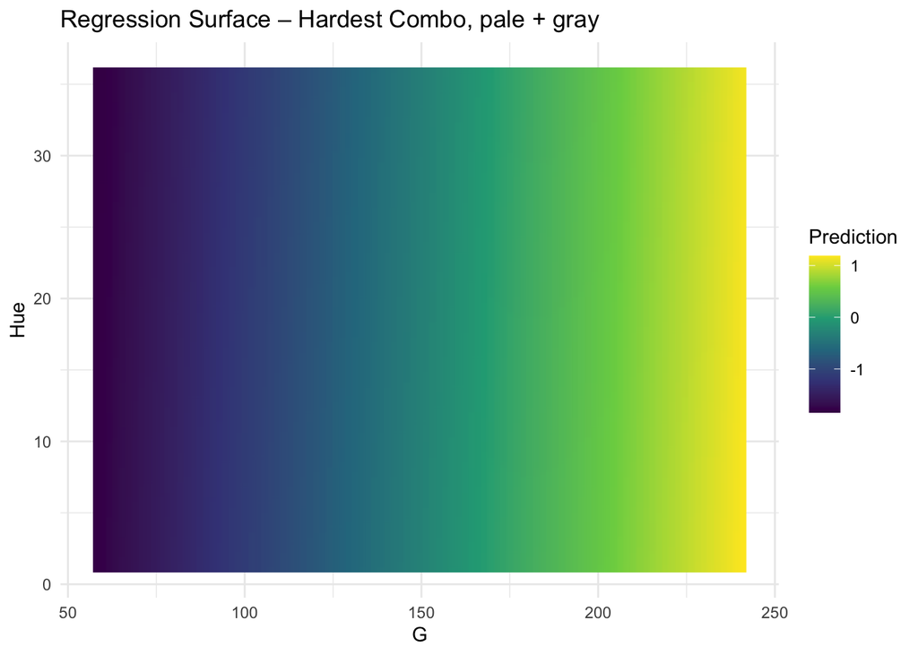

```r
# Regression – hardest combo
reg_grid_hard <- generate_surface_df(lin_add, dfii, fixed_vals = fixed_reg, type = "regression")
plot_surface(reg_grid_hard, "G", "Hue", "Regression Surface – Hardest Combo, pale + gray")
```